# Importing Libraries:

We import all the necessary libraries for implementing machine learning models such as sklearn, scikitlearn, scipy, numpy, pandas and visualization libraries like matplotlib, seaborn

```python
import numpy as np
import matplotlib.pyplot as plt
import seaborn as sns
import warnings
import matplotlib.pyplot as plt
import seaborn as sns
import numpy as np
from scipy.stats import norm
from sklearn.preprocessing import StandardScaler
from sklearn import preprocessing
import statsmodels.api as sm
from scipy import stats
import pandas as pandas # data processing, CSV file I/O (e.g. pd.read_csv)
#########
import seaborn as sns
from sklearn.ensemble import RandomForestClassifier
import matplotlib
from sklearn import tree
%matplotlib inline
from matplotlib import pyplot
import matplotlib.pyplot as plt
import seaborn
from sklearn.ensemble import RandomForestClassifier
from sklearn import metrics
import pandas as pd
import matplotlib.pyplot as plt
from sklearn.metrics import roc_curve, auc
from sklearn.model_selection import train_test_split
from sklearn.externals.six import StringIO



from sklearn import metrics
import pandas as pd
import matplotlib.pyplot as plt
from sklearn.metrics import roc_curve, auc
from sklearn.model_selection import train_test_split
import numpy as numpy
import pandas as pandas
import statsmodels.api
import statsmodels.formula.api as smf
import statsmodels.api as sm

import statsmodels.stats.multicomp as multi

import scipy
import matplotlib.pyplot as plt
import warnings

from sklearn.model_selection import train_test_split
from sklearn.tree import DecisionTreeClassifier
from sklearn.metrics import classification_report
import sklearn.metrics
from sklearn.ensemble import ExtraTreesClassifier

warnings.simplefilter(action = "ignore", category = FutureWarning)
from subprocess import check_output
from sklearn.pipeline import Pipeline
import warnings
from sklearn.preprocessing import StandardScaler
from sklearn.decomposition import PCA
from sklearn.covariance import EllipticEnvelope
import statsmodels.api as sm
from sklearn.model_selection import train_test_split
from sklearn.linear_model import LogisticRegression
from sklearn.ensemble import RandomForestClassifier
from sklearn.ensemble import GradientBoostingClassifier
from sklearn import metrics
warnings.filterwarnings('ignore')

# Input data files are available in the "../input/" directory.
# For example, running this (by clicking run or pressing Shift+Enter) will list all files under the input directory

import os
for dirname, _, filenames in os.walk('/kaggle/input'):
    for filename in filenames:
        print(os.path.join(dirname, filename))
```

# Dataset:

We refer the dataset to various names for easier reference for proving some of our conclusions

```python
dataset = pd.read_csv('Speed Dating Data.csv', encoding="ISO-8859-1")
 #yuck lots of objects and floats
data1 = pandas.read_csv("Speed Dating Data.csv", encoding="ISO-8859-1")
df = pd.DataFrame.from_csv("Speed Dating Data.csv", encoding="ISO-8859-1")
train = pd.read_csv('Speed Dating Data.csv', encoding="ISO-8859-1")
train.head()
```

|  | iid | id | gender | idg | condtn | wave | round | position | positin1 | order | ... | attr3_3 | sinc3_3 | intel3_3 | fun3_3 | amb3_3 | attr5_3 | sinc5_3 | intel5_3 | fun5_3 | amb5_3 |
| --- | --- | --- | --- | --- | --- | --- | --- | --- | --- | --- | --- | --- | --- | --- | --- | --- | --- | --- | --- | --- | --- |
| 0 | 1 | 1.0 | 0 | 1 | 1 | 1 | 10 | 7 | NaN | 4 | ... | 5.0 | 7.0 | 7.0 | 7.0 | 7.0 | NaN | NaN | NaN | NaN | NaN |
| 1 | 1 | 1.0 | 0 | 1 | 1 | 1 | 10 | 7 | NaN | 3 | ... | 5.0 | 7.0 | 7.0 | 7.0 | 7.0 | NaN | NaN | NaN | NaN | NaN |
| 2 | 1 | 1.0 | 0 | 1 | 1 | 1 | 10 | 7 | NaN | 10 | ... | 5.0 | 7.0 | 7.0 | 7.0 | 7.0 | NaN | NaN | NaN | NaN | NaN |
| 3 | 1 | 1.0 | 0 | 1 | 1 | 1 | 10 | 7 | NaN | 5 | ... | 5.0 | 7.0 | 7.0 | 7.0 | 7.0 | NaN | NaN | NaN | NaN | NaN |
| 4 | 1 | 1.0 | 0 | 1 | 1 | 1 | 10 | 7 | NaN | 7 | ... | 5.0 | 7.0 | 7.0 | 7.0 | 7.0 | NaN | NaN | NaN | NaN | NaN |

5 rows × 195 columns

# Data exploration:

We view and analyse the data with respect to different column variables

```python
train.columns #wow that's a lot of features
```

```
Index(['iid', 'id', 'gender', 'idg', 'condtn', 'wave', 'round', 'position',
       'positin1', 'order',
       ...
       'attr3_3', 'sinc3_3', 'intel3_3', 'fun3_3', 'amb3_3', 'attr5_3',
       'sinc5_3', 'intel5_3', 'fun5_3', 'amb5_3'],
      dtype='object', length=195)
```

```python
train.dtypes
```

```
iid           int64
id          float64
gender        int64
idg           int64
condtn        int64
wave          int64
round         int64
position      int64
positin1    float64
order         int64
partner       int64
pid         float64
match         int64
int_corr    float64
samerace      int64
age_o       float64
race_o      float64
pf_o_att    float64
pf_o_sin    float64
pf_o_int    float64
pf_o_fun    float64
pf_o_amb    float64
pf_o_sha    float64
dec_o         int64
attr_o      float64
sinc_o      float64
intel_o     float64
fun_o       float64
amb_o       float64
shar_o      float64
             ...
amb1_3      float64
shar1_3     float64
attr7_3     float64
sinc7_3     float64
intel7_3    float64
fun7_3      float64
amb7_3      float64
shar7_3     float64
attr4_3     float64
sinc4_3     float64
intel4_3    float64
fun4_3      float64
amb4_3      float64
shar4_3     float64
attr2_3     float64
sinc2_3     float64
intel2_3    float64
fun2_3      float64
amb2_3      float64
shar2_3     float64
attr3_3     float64
sinc3_3     float64
intel3_3    float64
fun3_3      float64
amb3_3      float64
attr5_3     float64
sinc5_3     float64
intel5_3    float64
fun5_3      float64
amb5_3      float64
Length: 195, dtype: object
```

```python
train['match'].describe()
```

```
count    8378.000000
mean        0.164717
std         0.370947
min         0.000000
25%         0.000000
50%         0.000000
75%         0.000000
max         1.000000
Name: match, dtype: float64
```

We see the distribution of data variables

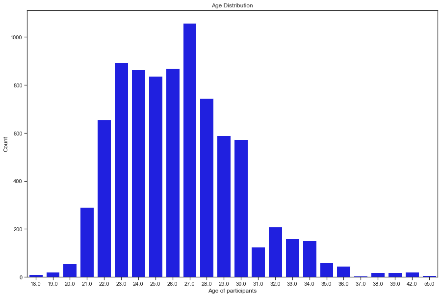

```python
# Age distribution of the participants
plt.figure(figsize = (15,10))
sns.countplot(x = 'age', data= dataset, color = 'blue')
plt.xlabel('Age of participants')
plt.ylabel('Count')
plt.title('Age Distribution')
plt.show()
```

# Check for missing values in age

```python
dataset['age'].isnull().sum()
```

```
95
```

Lets create a utility function to fill the missing values in the column with the value provided

```python
import math
def fill_missing_values(column_name, value):
    for i in range(len(dataset[column_name].values)):
        if math.isnan(dataset[column_name][i]):
            dataset[column_name][i] = value
import statistics
median = statistics.mode(dataset['age'].values)
fill_missing_values('age', median)
```

Check if there are still any missing values

```python
dataset['age'].isnull().sum()
```

```
0
```

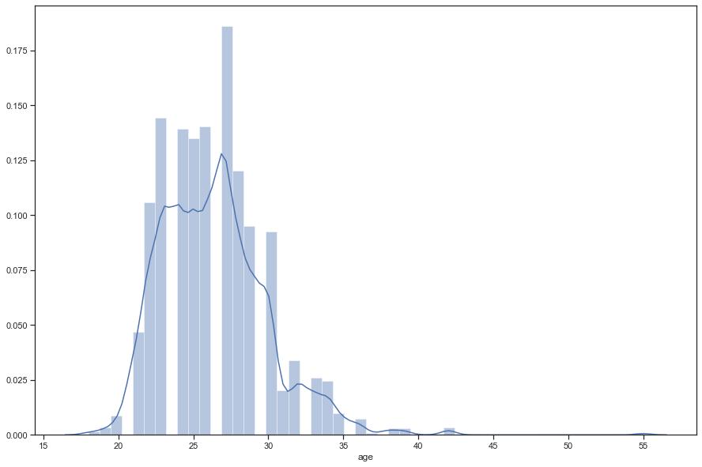

```python
plt.figure(figsize = (15,10))
sns.distplot(dataset['age'])
```

## Lets apply KMeans clustering algorithm between Gender and age

Lets create utility function to Get the Within Cluster Sum of Squares (WCSS) and plot the Elbow curve so that we can decide optimum number of clusters

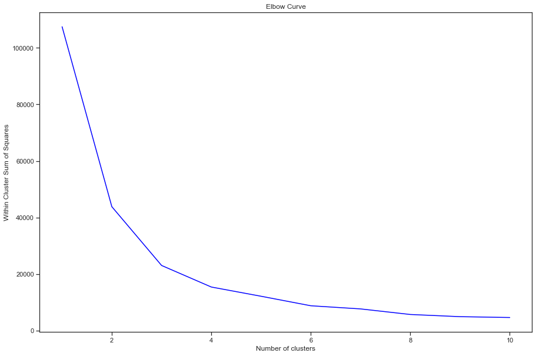

```python
x = dataset[['gender', 'age']].values
from sklearn.cluster import KMeans

def get_wcss(x):
    wcss = []
    for i in range(1,11):
        kmeans = KMeans(n_clusters = i, init = 'k-means++')
        kmeans.fit(x)
        wcss.append(kmeans.inertia_)
    return wcss

def plot_elbow_curve(wcss):
    plt.figure(figsize = (15,10))
    plt.plot(range(1,11), wcss, color = 'blue')
    plt.xlabel('Number of clusters')
    plt.ylabel('Within Cluster Sum of Squares')
    plt.title('Elbow Curve')
    plt.show()
wcss = get_wcss(x)
plot_elbow_curve(wcss)
```

We here choose K value to be 6 for this dataset to form clusters

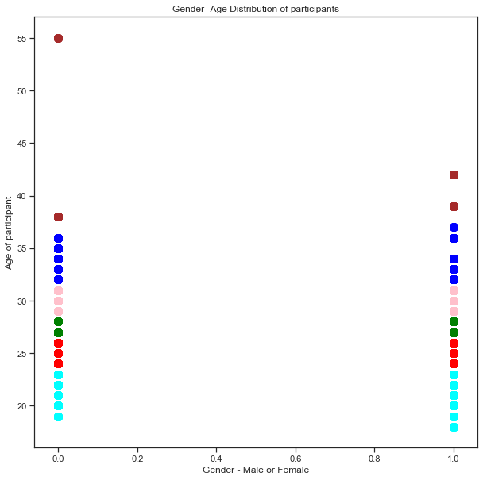

```python
kmeans = KMeans(n_clusters = 6, init = 'k-means++')
y_clusters = kmeans.fit_predict(x)
plt.figure(figsize = (10,10))
plt.scatter(x[y_clusters == 0, 0], x[y_clusters == 0, 1], s = 100, c = 'red', label = 'Cluster-1')
plt.scatter(x[y_clusters == 1, 0], x[y_clusters == 1, 1], s = 100, c = 'blue', label = 'Cluster-2')
plt.scatter(x[y_clusters == 2, 0], x[y_clusters == 2, 1], s = 100, c = 'green', label = 'Cluster-3')
plt.scatter(x[y_clusters == 3, 0], x[y_clusters == 3, 1], s = 100, c = 'cyan', label = 'Cluster-4')
plt.scatter(x[y_clusters == 4, 0], x[y_clusters == 4, 1], s = 100, c = 'brown', label = 'Cluster-5')
plt.scatter(x[y_clusters == 5, 0], x[y_clusters == 5, 1], s = 100, c = 'pink', label = 'Cluster-6')

plt.xlabel('Gender - Male or Female')
plt.ylabel('Age of participant')
plt.title('Gender- Age Distribution of participants')
plt.show()
```

# We combine certain columns to make more rows in it

```python
dating_1 = train.iloc[:, 11:28]
dating_2 = train.iloc[:, 30:35]
dating_3 = train.iloc[:, 39:43]
dating_4 = train.iloc[:, 45:67]
dating_5 = train.iloc[:, 69:74]
dating_6 = train.iloc[:, 87:91]
dating_7 = train.iloc[:, 97:102]
dating_8 = train.iloc[:, 104:107]
date = pd.concat([train.iloc[:, 0],train.iloc[:, 2],dating_1,dating_2,dating_3,dating_4,dating_5,
                  dating_6,dating_7,dating_8], axis=1)

columns = date.select_dtypes(include=[object])
print(columns)
```

```
                 field               from  \
0                  Law            Chicago
1                  Law            Chicago
2                  Law            Chicago
3                  Law            Chicago
4                  Law            Chicago
5                  Law            Chicago
6                  Law            Chicago
7                  Law            Chicago
8                  Law            Chicago
9                  Law            Chicago
10                 law            Alabama
11                 law            Alabama
12                 law            Alabama
13                 law            Alabama
```

[output cut: 112 more lines]

We can see in Heat map that Age seems to be correlated with going out

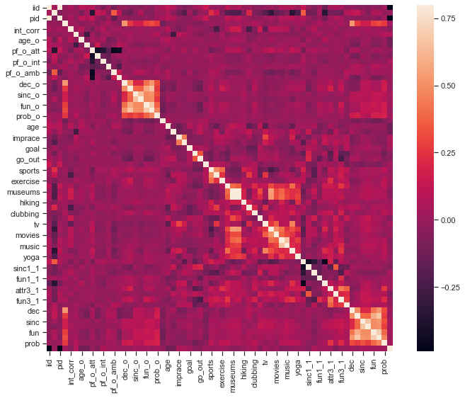

```python
cols_with_missing = [col for col in date.columns
                                 if date[col].isnull().any()]
candidate_train_predictors = date.drop(['iid'] + cols_with_missing, axis=1)


# "cardinality" means the number of unique values in a column.
# We use it as our only way to select categorical columns here. This is convenient, though
# a little arbitrary.
low_cardinality_cols = [cname for cname in candidate_train_predictors.columns if
                                candidate_train_predictors[cname].nunique() < 191 and
                                candidate_train_predictors[cname].dtype == "object"]
numeric_cols = [cname for cname in candidate_train_predictors.columns if
                                candidate_train_predictors[cname].dtype in ['int64', 'float64']]
my_cols = low_cardinality_cols + numeric_cols
train_predictors = candidate_train_predictors[my_cols]

# Create a label (category) encoder object
#le = preprocessing.LabelEncoder()

# Fit the encoder to the pandas column
#le.fit(date[''])

# Standardize the feature matrix
#X = StandardScaler().fit_transform(speed)

speed = date.dropna() #dropping missing values

#dropping highly correlated features
# Create correlation matrix
corr_matrix = speed.corr().abs()

# Select upper triangle of correlation matrix
upper = corr_matrix.where(np.triu(np.ones(corr_matrix.shape), k=1).astype(np.bool))

# Find index of feature columns with correlation greater than 0.95
to_drop = [column for column in upper.columns if any(upper[column] > 0.95)]

corrmat = speed.corr()
f, ax = plt.subplots(figsize=(12, 9))
sns.heatmap(corrmat, vmax=.8, square=True);
```

# To find outliers

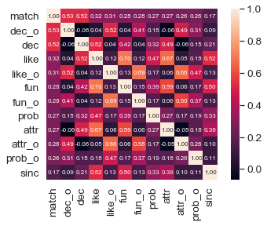

```python
#match correlation matrix
k = 12 #number of variables for heatmap
cols = corrmat.nlargest(k, 'match')['match'].index
cm = np.corrcoef(speed[cols].values.T)
sns.set(font_scale=1.25)
hm = sns.heatmap(cm, cbar=True, annot=True, square=True, fmt='.2f', annot_kws={'size': 8}, yticklabels=cols.values, xticklabels=cols.values)
plt.show()
```

Taking a closer look we see that match is highly correlated with final decision (this should've been deleted since this is similar to match) in this dataset and that a person is more likeable if they have nice attributes and are fun.Note that from here on any feature with '_o' means that that's their partner's trait

# We can now observe who is ideal to date - male or female?

```python
speed[speed['gender'] == 1].mean() #male
```

```
iid         290.454948
gender        1.000000
pid         273.565731
match         0.176071
int_corr      0.202369
samerace      0.398523
age_o        26.021566
race_o        2.837223
pf_o_att     17.796021
pf_o_sin     18.337905
pf_o_int     21.071294
pf_o_fun     17.258133
pf_o_amb     12.892541
pf_o_sha     12.642996
dec_o         0.384047
attr_o        5.968390
sinc_o        7.126440
intel_o       7.487445
fun_o         6.311965
like_o        6.045643
prob_o        5.296898
met_o         1.956278
age          26.584047
race          2.744756
imprace       3.451403
imprelig      3.077400
goal          2.122009
date          4.838405
go_out        2.139439
career_c      5.208272
               ...
museums       6.619202
art           6.265288
hiking        5.551551
gaming        4.449926
clubbing      5.551256
reading       7.476219
tv            4.837223
theater       6.116691
movies        7.702806
concerts      6.534712
music         7.729690
shopping      4.771935
yoga          3.781093
attr1_1      26.399696
sinc1_1      16.660284
intel1_1     19.640526
fun1_1       17.677217
amb1_1        8.601770
attr3_1       6.978139
sinc3_1       8.161891
fun3_1        7.517873
intel3_1      8.507829
dec           0.488922
attr          6.443250
sinc          7.240620
intel         7.284343
fun           6.519202
like          6.272437
prob          5.222009
met           0.923486
Length: 64, dtype: float64
```

Men prefer women who are attractive, younger and have shared interests.

```python
speed[speed['gender'] == 0].mean()
```

```
iid         276.908265
gender        0.000000
pid         293.875147
match         0.173505
int_corr      0.197057
samerace      0.400059
age_o        26.598769
race_o        2.747362
pf_o_att     26.423889
pf_o_sin     16.656753
pf_o_int     19.677597
pf_o_fun     17.697878
pf_o_amb      8.580530
pf_o_sha     11.070223
dec_o         0.484467
attr_o        6.444431
sinc_o        7.251319
intel_o       7.284144
fun_o         6.525059
like_o        6.257825
prob_o        5.191237
met_o         1.956917
age          26.068288
race          2.835580
imprace       4.099648
imprelig      4.257034
goal          2.080012
date          5.152696
go_out        2.138335
career_c      5.220985
               ...
museums       7.479777
art           7.272274
hiking        5.920868
gaming        3.349355
clubbing      5.927022
reading       7.930539
tv            5.786049
theater       7.512016
movies        8.214244
concerts      7.090563
music         7.963951
shopping      6.597890
yoga          4.994138
attr1_1      17.845700
sinc1_1      18.319991
intel1_1     21.078643
fun1_1       17.209197
amb1_1       12.925923
attr3_1       7.245897
sinc3_1       8.458089
fun3_1        7.916178
intel3_1      8.356389
dec           0.381887
attr          5.936841
sinc          7.110492
intel         7.466589
fun           6.289566
like          6.020076
prob          5.262309
met           0.926143
Length: 64, dtype: float64
```

## Does shared interest play a vital role in finding dating mate?

```python
speed.pivot_table(['race', 'pf_o_sha'],
               ['match'], aggfunc='sum')
```

| match | pf_o_sha | race |
| --- | --- | --- |
| 0 | 67320.27 | 15701.0 |
| 1 | 13247.87 | 3265.0 |

With pivot table unfortunately we can't normalize so calculating the percentage of matches made for preferred common interests and race are 16.4% and 17.2% so race and shared interests are somewhat similar and have an equal degree of importance

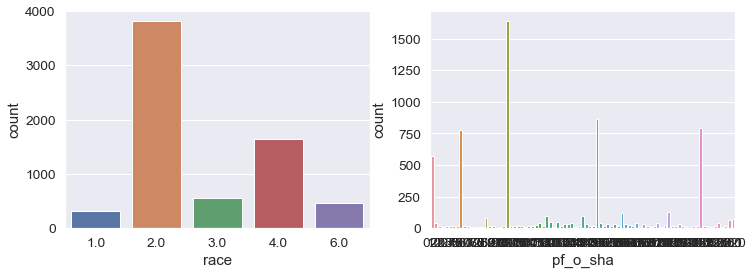

```python
_, axes = plt.subplots(nrows=1, ncols=2, figsize=(12, 4))

sns.countplot(x='race', data=speed, ax=axes[0]);
sns.countplot(x='pf_o_sha', data=speed, ax=axes[1]);
```

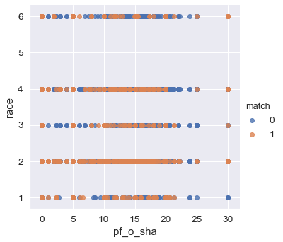

```python
sns.lmplot('pf_o_sha', 'race', data=speed, hue='match', fit_reg=False);
```

## Now we'll check for accuracy using various algorithms

```python
X=speed[['like','fun','attr']]
y=speed['match']
X_train, X_test, y_train, y_test = train_test_split(X, y, test_size=0.15, random_state=3, stratify=y)
```

```python
# logistic regression classification model
model = LogisticRegression(C=3, random_state=43)
lrc = model.fit(X_train, y_train)
predict_train_lrc = lrc.predict(X_train)
predict_test_lrc = lrc.predict(X_test)
print('Training Accuracy:', metrics.accuracy_score(y_train, predict_train_lrc))
print('Validation Accuracy:', metrics.accuracy_score(y_test, predict_test_lrc))
```

```
Training Accuracy: 0.8236108706941319
Validation Accuracy: 0.8196078431372549
```

```python
#RandomForestClassifier
model = RandomForestClassifier()
rf_model = model.fit(X_train, y_train)
predict_train_rf = rf_model.predict(X_train)
predict_test_rf = rf_model.predict(X_test)
print('Training Accuracy:', metrics.accuracy_score(y_train, predict_train_rf))
print('Validation Accuracy:', metrics.accuracy_score(y_test, predict_test_rf))
```

```
Training Accuracy: 0.8352085857711615
Validation Accuracy: 0.8117647058823529
```

```python
# xgboost model
model = GradientBoostingClassifier()
xgb_model = model.fit(X_train, y_train)
predict_train_xgb = xgb_model.predict(X_train)
predict_test_xgb = xgb_model.predict(X_test)
print('Training Accuracy:', metrics.accuracy_score(y_train, predict_train_xgb))
print('Validation Accuracy:', metrics.accuracy_score(y_test, predict_test_xgb))
```

```
Training Accuracy: 0.8294962783451618
Validation Accuracy: 0.8245098039215686
```

# Does gender difference exist in dating

```python
##Selecting Only the Relevant Variables for the Analysis
temp1=data1[['iid','gender','pid','samerace','age_o','race_o','dec_o','attr_o','sinc_o','intel_o','fun_o','amb_o','shar_o','like_o','prob_o','age','field_cd','race','imprace','imprelig','from','date','go_out','dec','attr','sinc','intel','fun','amb','shar','like','prob']]

#Creation DataSet for Merging Missing Variables
temp2=temp1[['iid','field_cd','imprace','imprelig','from','date','go_out']]
#Rename the variables to avoid confusion with the two data frames...
temp2.columns = ['pid','field_cd_o','imprace_o','imprelig_o','from_0','date_0','go_out_o']
#Merge the two datasets to have all the variables for both the partners.
BothGenders=pandas.merge(temp1,temp2,on='pid')

BothGenders=BothGenders.drop('iid',1)
BothGenders=BothGenders.drop('pid',1)
BothGenders=BothGenders.dropna()


#Difference of the age between the parther instead of the "absolute" age.
BothGenders['Delta_Age']=BothGenders['age'] - BothGenders['age_o']
#Same field of career
BothGenders['SameField']=BothGenders['field_cd'] == BothGenders['field_cd_o']
#Provenience from the state.
BothGenders['SameState']=BothGenders['from'] == BothGenders['from_0']
BothGenders=BothGenders.drop('from',1)
BothGenders=BothGenders.drop('from_0',1)


#Subset the dataframe for the two genders From now on we will use only these two datasets.
Females=BothGenders.loc[BothGenders['gender'] == 0]
Males=BothGenders.loc[BothGenders['gender'] == 1]


#Average for all the Features Group by 'dec' factor
#Females
Females[Females.columns[:]].groupby(Females['dec']).mean().round(2)
```

| dec | gender | samerace | age_o | race_o | dec_o | attr_o | sinc_o | intel_o | fun_o | amb_o | ... | like | prob | field_cd_o | imprace_o | imprelig_o | date_0 | go_out_o | Delta_Age | SameField | SameState |
| --- | --- | --- | --- | --- | --- | --- | --- | --- | --- | --- | --- | --- | --- | --- | --- | --- | --- | --- | --- | --- | --- |
| 0 | 0.0 | 0.37 | 26.60 | 2.80 | 0.51 | 6.48 | 7.06 | 7.14 | 6.40 | 6.47 | ... | 5.29 | 4.78 | 7.35 | 3.63 | 3.13 | 4.97 | 2.24 | -0.75 | 0.11 | 0.01 |
| 1 | 0.0 | 0.42 | 26.45 | 2.58 | 0.46 | 6.26 | 7.46 | 7.48 | 6.62 | 6.71 | ... | 7.18 | 5.96 | 7.47 | 3.59 | 3.05 | 4.63 | 1.95 | -0.57 | 0.15 | 0.01 |

2 rows × 37 columns

```python
#Males
Males[Males.columns[:]].groupby(Males['dec']).mean().round(2)
```

| dec | gender | samerace | age_o | race_o | dec_o | attr_o | sinc_o | intel_o | fun_o | amb_o | ... | like | prob | field_cd_o | imprace_o | imprelig_o | date_0 | go_out_o | Delta_Age | SameField | SameState |
| --- | --- | --- | --- | --- | --- | --- | --- | --- | --- | --- | --- | --- | --- | --- | --- | --- | --- | --- | --- | --- | --- |
| 0 | 1.0 | 0.39 | 25.93 | 2.95 | 0.40 | 6.05 | 6.90 | 7.34 | 6.19 | 6.82 | ... | 5.28 | 4.50 | 8.13 | 4.24 | 4.32 | 5.20 | 2.23 | 0.73 | 0.10 | 0.01 |
| 1 | 1.0 | 0.40 | 25.81 | 2.74 | 0.35 | 5.83 | 7.23 | 7.57 | 6.37 | 7.03 | ... | 7.19 | 5.95 | 8.11 | 4.25 | 4.21 | 5.13 | 2.09 | 0.63 | 0.14 | 0.01 |

2 rows × 37 columns

# ANOVA Analysis

Females

```python
model1 = smf.ols(formula='dec ~ C(samerace)+age_o+C(race_o)+dec_o+attr_o+sinc_o+intel_o+fun_o+amb_o+shar_o+like_o+prob_o+imprace+imprelig+date+go_out+attr+sinc+intel+fun+amb+shar+like+prob+age+age_o+Delta_Age+go_out_o+date_0+C(race)', data=Females)
results1 = model1.fit()

table = sm.stats.anova_lm(results1, typ=2)


FeaturesImportance=sorted(zip(table.F,table.index),reverse=True)
dfFemales = pandas.DataFrame(FeaturesImportance, columns=['Model.Feature_Importances_Based_on_F', 'predictors.columns'])
print("Top 10 Features with the highest F value")
print(dfFemales.head(10).round(2))
```

```
Top 10 Features with the highest F value
   Model.Feature_Importances_Based_on_F predictors.columns
0                               1316.63               like
1                               1093.92               attr
2                                533.17             attr_o
3                                379.04               shar
4                                366.71            C(race)
5                                360.49               prob
6                                327.71        C(samerace)
7                                247.59             prob_o
8                                134.75               sinc
9                                116.37                fun
```

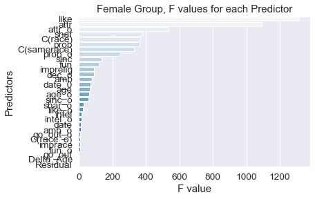

```python
ax0=sns.barplot(y="predictors.columns", x="Model.Feature_Importances_Based_on_F", data=dfFemales,
             palette="Blues")
ax0.set(ylabel='Predictors', xlabel='F value',title="Female Group, F values for each Predictor")
plt.show()
```

We can clearly see women date based on like or similar interests

Below few BoxPlots to visualize few of the top variables on the two codition of "dec"

```
array([[<matplotlib.axes._subplots.AxesSubplot object at 0x000002178686EAC8>,
      dtype=object)
```

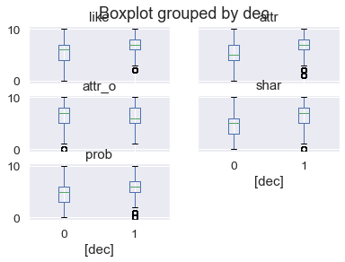

```python
Females.boxplot(column=['like','attr','attr_o','shar','prob'], by=['dec'])
```

The Same analysis for the Males

```python
model1 = smf.ols(formula='dec ~ C(samerace)+age_o+C(race_o)+dec_o+attr_o+sinc_o+intel_o+fun_o+amb_o+shar_o+like_o+prob_o+imprace+imprelig+date+go_out+attr+sinc+intel+fun+amb+shar+like+prob+age+age_o+Delta_Age+go_out_o+date_0+C(race)', data=Males)
results1 = model1.fit()

table = sm.stats.anova_lm(results1, typ=2)


FeaturesImportance=sorted(zip(table.F,table.index),reverse=True)
dfMales = pandas.DataFrame(FeaturesImportance, columns=['Model.Feature_Importances_Based_on_F', 'predictors.columns'])
print("Top 10 Features with the highest F value")
print(dfMales.head(10))
```

```
Top 10 Features with the highest F value
   Model.Feature_Importances_Based_on_F predictors.columns
0                           3158.150321               attr
1                           2620.042686               like
2                            802.125591               prob
3                            430.722457               sinc
4                            390.236235                amb
5                            155.712514               date
6                            153.864091             attr_o
7                            141.762974            imprace
8                            133.352701             go_out
9                            132.115839               shar
```

We can clearly see men date based on attraction then on like or similar interests

Below few BoxPlots to visualize few of the top variables on the two codition of "dec"

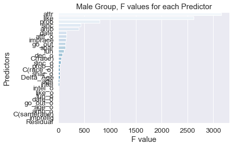

```python
ax1=sns.barplot(y="predictors.columns", x="Model.Feature_Importances_Based_on_F", data=dfMales,palette="Blues")
ax1.set(ylabel='Predictors', xlabel='F value',title="Male Group, F values for each Predictor")
plt.show()
```

```
array([[<matplotlib.axes._subplots.AxesSubplot object at 0x00000217F1FE8F28>,
      dtype=object)
```

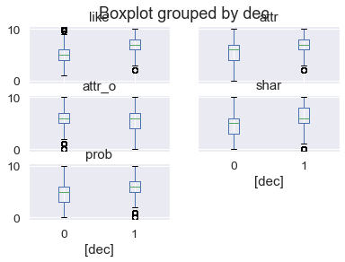

```python
Males.boxplot(column=['like','attr','attr_o','shar','prob'], by=['dec'])
```

## Now we'll check who has more market value

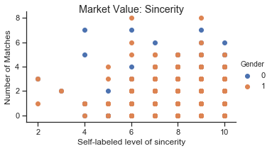

```python
%matplotlib inline
from matplotlib import pyplot
import matplotlib.pyplot as plt
import pandas as pd
import seaborn
seaborn.set(style='ticks')
df = pd.DataFrame.from_csv("Speed Dating Data.csv", encoding="ISO-8859-1")
keep_cols = ["attr3_1", "sinc3_1", "intel3_1", "fun3_1", "amb3_1", "match", "expnum", "gender"]
df = df[keep_cols]
actual_matches = []
actual_matches = [(df.iloc[i:i+10-1].sum(axis=0)["match"])for i in range(0, len(df), 10)]
#adding up all the matches for every 10 rows to find total number of actual matches for each ID.
df = df.iloc[::10, :]
df["match"] = actual_matches

low_memory = False
_genders= [0, 1]
df = pd.DataFrame({
    'Self-labeled level of sincerity': df["sinc3_1"],
    'Number of Matches': df["match"],
    'Gender': df["gender"]
})

ax2 = seaborn.FacetGrid(data=df, hue='Gender', hue_order=_genders, aspect=1.61)
ax2.map(pyplot.scatter, 'Self-labeled level of sincerity','Number of Matches').add_legend()
%matplotlib inline
from matplotlib import pyplot
import matplotlib.pyplot as plt
import pandas as pd
import seaborn
seaborn.set(style='ticks')
df = pd.DataFrame.from_csv("Speed Dating Data.csv", encoding="ISO-8859-1")
keep_cols = ["attr3_1", "sinc3_1", "intel3_1", "fun3_1", "amb3_1", "match", "expnum", "gender"]
df = df[keep_cols]
actual_matches = []
actual_matches = [(df.iloc[i:i+10-1].sum(axis=0)["match"])for i in range(0, len(df), 10)]
#adding up all the matches for every 10 rows to find total number of actual matches for each ID.
df = df.iloc[::10, :]
df["match"] = actual_matches

low_memory = False
_genders= [0, 1]
df = pd.DataFrame({
    'Self-labeled level of sincerity': df["sinc3_1"],
    'Number of Matches': df["match"],
    'Gender': df["gender"]
})

ax2 = seaborn.FacetGrid(data=df, hue='Gender', hue_order=_genders, aspect=1.61)
ax2.map(pyplot.scatter, 'Self-labeled level of sincerity','Number of Matches').add_legend()
ax2.fig.suptitle("Market Value: Sincerity")
```

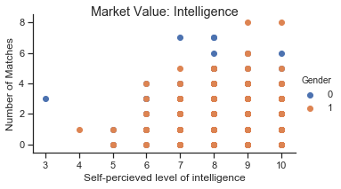

```python
df = pd.DataFrame.from_csv("Speed Dating Data.csv", encoding="ISO-8859-1")
keep_cols = ["attr3_1", "sinc3_1", "intel3_1", "fun3_1", "amb3_1", "match", "expnum", "gender"]
df = df[keep_cols]
#adding up all the matches for every 10 rows to find total number of actual matches for each ID.
actual_matches = []
actual_matches = [(df.iloc[i:i+10-1].sum(axis=0)["match"])for i in range(0, len(df), 10)]
df = df[keep_cols]
#df['match']  = actual_matches
df = df.iloc[::10, :]
df["match"] = actual_matches

_genders= [0, 1]
df = pd.DataFrame({
    'Self-percieved level of intelligence': df["intel3_1"],
    'Number of Matches': df["match"],
    'Gender': df["gender"]
})

ax2 = seaborn.FacetGrid(data=df, hue='Gender', hue_order=_genders, aspect=1.61)
ax2.map(pyplot.scatter, 'Self-percieved level of intelligence','Number of Matches').add_legend()
ax2.fig.suptitle("Market Value: Intelligence")
```

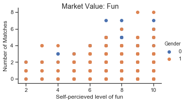

```python
df = pd.DataFrame.from_csv("Speed Dating Data.csv", encoding="ISO-8859-1")
keep_cols = ["attr3_1", "sinc3_1", "intel3_1", "fun3_1", "amb3_1", "match", "expnum", "gender"]
df = df[keep_cols]
#adding up all the matches for every 10 rows to find total number of actual matches for each ID.
actual_matches = []
actual_matches = [(df.iloc[i:i+10-1].sum(axis=0)["match"])for i in range(0, len(df), 10)]
df = df[keep_cols]
#df['match']  = actual_matches
df = df.iloc[::10, :]
df["match"] = actual_matches

_genders= [0, 1]
df = pd.DataFrame({
    'Self-percieved level of fun': df["fun3_1"],
    'Number of Matches': df["match"],
    'Gender': df["gender"]
})

ax2 = seaborn.FacetGrid(data=df, hue='Gender', hue_order=_genders, aspect=1.61)
ax2.map(pyplot.scatter, 'Self-percieved level of fun','Number of Matches').add_legend()
ax2.fig.suptitle("Market Value: Fun")
```

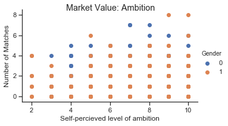

```python
df = pd.DataFrame.from_csv("Speed Dating Data.csv", encoding="ISO-8859-1")
keep_cols = ["attr3_1", "sinc3_1", "intel3_1", "fun3_1", "amb3_1", "match", "expnum", "gender"]
df = df[keep_cols]
#adding up all the matches for every 10 rows to find total number of actual matches for each ID.
actual_matches = []
actual_matches = [(df.iloc[i:i+10-1].sum(axis=0)["match"])for i in range(0, len(df), 10)]
df = df[keep_cols]
#df['match']  = actual_matches
df = df.iloc[::10, :]
df["match"] = actual_matches

_genders= [0, 1]
df = pd.DataFrame({
    'Self-percieved level of ambition': df["amb3_1"],
    'Number of Matches': df["match"],
    'Gender': df["gender"]
})

ax2 = seaborn.FacetGrid(data=df, hue='Gender', hue_order=_genders, aspect=1.61)
ax2.map(pyplot.scatter, 'Self-percieved level of ambition','Number of Matches').add_legend()
ax2.fig.suptitle("Market Value: Ambition")
```

```python
import scipy
import numpy as np, scipy.stats as st
import math
from numpy import sqrt, abs, round
from scipy.stats import norm
df = pd.DataFrame.from_csv("Speed Dating Data.csv", encoding="ISO-8859-1")
keep_cols = ["attr3_1", "sinc3_1", "intel3_1", "fun3_1", "amb3_1", "match", "expnum", "gender"]
df = df[keep_cols]
#adding up all the matches for every 10 rows to find total number of actual matches for each ID.
print("Women on Intelligence")
df_w = df[df["gender"] == 0]["intel3_1"]
print(df_w.mean())
print("Men on Intelligence")
df_m = df[df["gender"] == 1]["intel3_1"]
print(df_m.mean())
print("Women on Ambition")
df_w = df[df["gender"] == 0]["amb3_1"]
print(df_w.mean())

print("Men on Ambition")
df_m = df[df["gender"] == 1]["amb3_1"]
print(df_m.mean())
df_m = df[df["gender"]==1]
```

```
Women on Intelligence
8.320621811999029
Men on Intelligence
8.486525505293551
Women on Ambition
7.632499392761719
Men on Ambition
7.524783445620789
```